# DatasetExploration

```python
import glob
import numpy as np
import matplotlib.pyplot as plt
import cv2
import pickle
%matplotlib inline
```

First find all the images in the vehicle and non-vehicle categories and print a list of counts

```python
vehicle_set = glob.glob('dataset/vehicles/*')
vehicle_images = {}
for p in vehicle_set:
    p_name = p[p.rindex('/')+1:]
    image_files = glob.glob(p + '/*')
    vehicle_images[p_name] = image_files
```

```python
nonvehicle_set = glob.glob('dataset/non-vehicles/*')
nonvehicle_images = {}
for p in nonvehicle_set:
    p_name = p[p.rindex('/')+1:]
    image_files = glob.glob(p + '/*')
    nonvehicle_images[p_name] = image_files
```

```python
for p in nonvehicle_images:
    print(p, len(nonvehicle_images[p]))
```

```
Extras 5068
GTI 3900
```

```python
for p in vehicle_images:
    print(p, len(vehicle_images[p]))
```

```
GTI_Right 664
GTI_MiddleClose 419
GTI_Far 834
KITTI_extracted 5966
GTI_Left 909
```

```python
print('nonvehicle image count', sum(len(nonvehicle_images[p]) for p in nonvehicle_images))
print('vehicle image count', sum(len(vehicle_images[p]) for p in vehicle_images))
```

```
nonvehicle image count 8968
vehicle image count 8792
```

The classes are roughly balanced.

Save the above dataset name and filename information to a pickle.

```python
with open('dataset-description.pickle','wb') as f:
    pickle.dump((vehicle_images, nonvehicle_images), f)
```

```python
vehicle_data = {}
for p in vehicle_images:
    current_list = []
    for f in vehicle_images[p]:
        current_list.append(cv2.imread(f))
    vehicle_data[p] = current_list
```

```python
nonvehicle_data = {}
for p in nonvehicle_images:
    current_list = []
    for f in nonvehicle_images[p]:
        current_list.append(cv2.imread(f))
    nonvehicle_data[p] = current_list
```

Save those to a pickle as well.

```python
with open('dataset-data.pickle','wb') as f:
    pickle.dump((vehicle_data, nonvehicle_data), f)
```

Now we take a look at the dimensions of the images.

```python
vehicle_size = {}
for p in vehicle_data:
    counts = {}
    for f in vehicle_data[p]:
        if f.shape not in counts:
            counts[f.shape] = 0
        counts[f.shape] += 1
    vehicle_size[p] = counts
```

```python
vehicle_size
```

```
{'GTI_Far': {(64, 64, 3): 834},
 'GTI_Left': {(64, 64, 3): 909},
 'GTI_MiddleClose': {(64, 64, 3): 419},
 'GTI_Right': {(64, 64, 3): 664},
 'KITTI_extracted': {(64, 64, 3): 5966}}
```

```python
nonvehicle_size = {}
for p in nonvehicle_data:
    counts = {}
    for f in nonvehicle_data[p]:
        if f.shape not in counts:
            counts[f.shape] = 0
        counts[f.shape] += 1
    nonvehicle_size[p] = counts
```

```python
nonvehicle_size
```

```
{'Extras': {(64, 64, 3): 5068}, 'GTI': {(64, 64, 3): 3900}}
```

We see that they are all 64x64x3.

```python
def plot_random(data, n_samples = 5):
    plt.figure(figsize=(15,10))
    n_rows = len(data)
    for i,p in enumerate(data):
        samples = np.random.choice(len(data[p]), size=n_samples, replace=False)
        for j,imgidx in enumerate(samples):
            plt.subplot(n_rows, n_samples, i*n_samples+j+1)
            plt.imshow(data[p][imgidx][:,:,::-1])
            plt.title('{0} {1}'.format(p, imgidx))
    plt.tight_layout()
    plt.show()
```

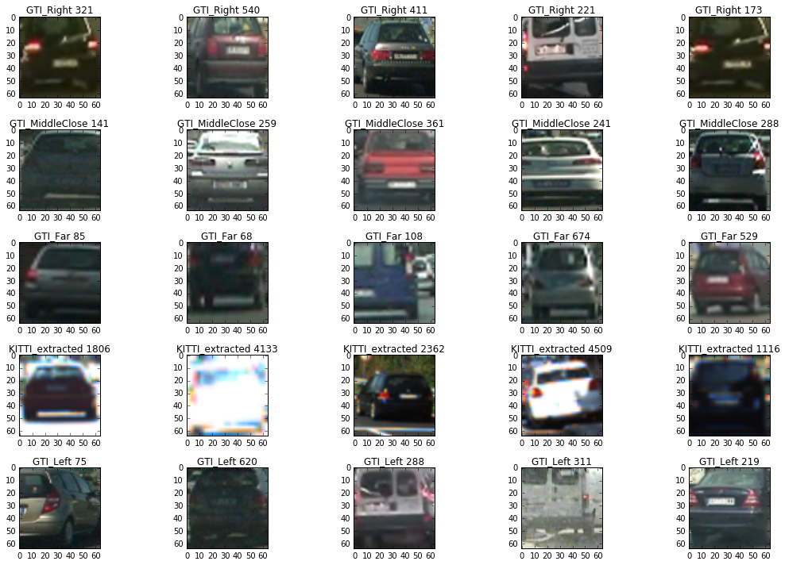

```python
plot_random(vehicle_data)
```

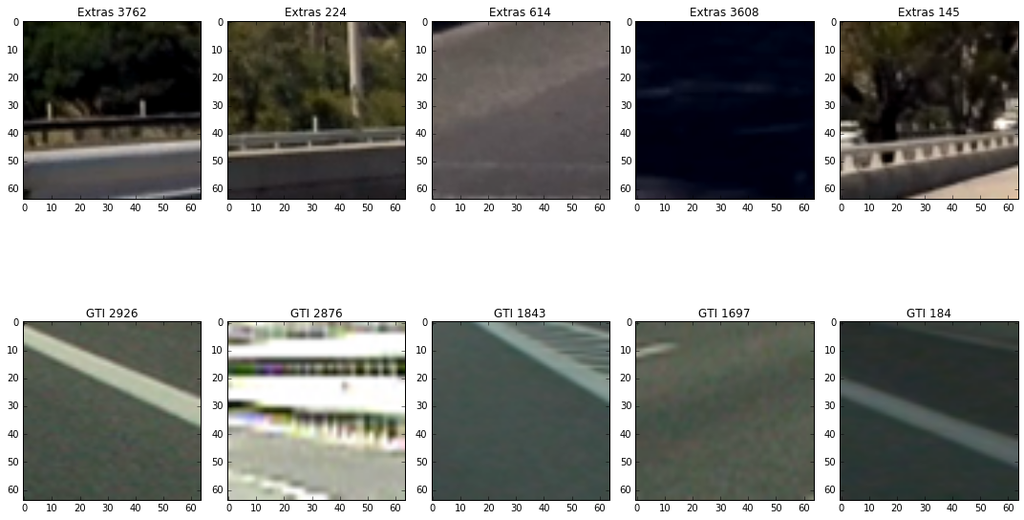

```python
plot_random(nonvehicle_data)
```

We see that vehicle data contains images of the rear of the vehicles. Some images contain the whole vehicle, while some contains only a crop.

Non-vehicle data consists of mostly other features on the road. Sometimes there is also a small part of some vehicle in the cropped frames.

```python
data = vehicle_data
for p in data:
    score = 0
    for img in data[p]:
        v_luv = cv2.cvtColor(img, cv2.COLOR_BGR2LUV)[:,:,2].astype(np.float)
        v_yuv = cv2.cvtColor(img, cv2.COLOR_BGR2YUV)[:,:,2].astype(np.float)
        mx = np.max(np.abs(v_luv-v_yuv))
        score += (mx <= 10)
    print(p, len(data[p]), score)
```

```
GTI_Right 664 0
GTI_MiddleClose 419 0
GTI_Far 834 3
KITTI_extracted 5966 0
GTI_Left 909 0
```

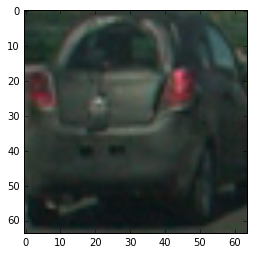

```python
plt.imshow(img[:,:,::-1])
```

```python
luv = cv2.cvtColor(img, cv2.COLOR_BGR2LUV)
```

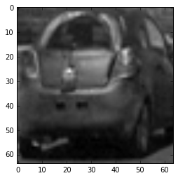

```python
plt.imshow(ycbcr[:,:,0], cmap='gray')
```

```python
from skimage.feature import hog
```

```python
def get_hog_features(img, n_orient=9, pix_per_cell=8, cell_per_block=2, \
                     transform_sqrt = False, \
                     vis=False, feature_vec=True):
    # in skimage 0.12.3 L2 block-normalization is applied automatically
    if vis:
        features, hog_image = hog(img, orientations=n_orient, \
                                  pixels_per_cell=(pix_per_cell, pix_per_cell), \
                                  cells_per_block=(cell_per_block, cell_per_block), \
                                  transform_sqrt=transform_sqrt, \
                                  visualise=vis, feature_vector=feature_vec)
        return features, hog_image
    else:
        features = hog(img, orientations=n_orient, \
                       pixels_per_cell=(pix_per_cell, pix_per_cell), \
                       cells_per_block=(cell_per_block, cell_per_block), \
                       transform_sqrt=transform_sqrt, \
                       visualise=vis, feature_vector=feature_vec)
        return features
```

```python
def channel_hist(img, nbins=32, bins_range=(0, 256)):
    # Compute the histogram of the color channels separately
    return np.histogram(img, bins=nbins, range=bins_range)
```

```python
cv2.COLOR_BGR2YCrCb
```

```
36
```

```python
y,r,b = np.dsplit(cv2.cvtColor(img, cv2.COLOR_BGR2YCrCb), 3)
```

```python
type(l)
```

```
list
```

```python
len(l)
```

```
3
```

```python
cv2.cvtColor(img, cv2.COLOR_BGR2YCrCb).shape
```

```
(64, 64, 3)
```